# *Aura Zuluaga*

## **s4630375**

# Assignment 1

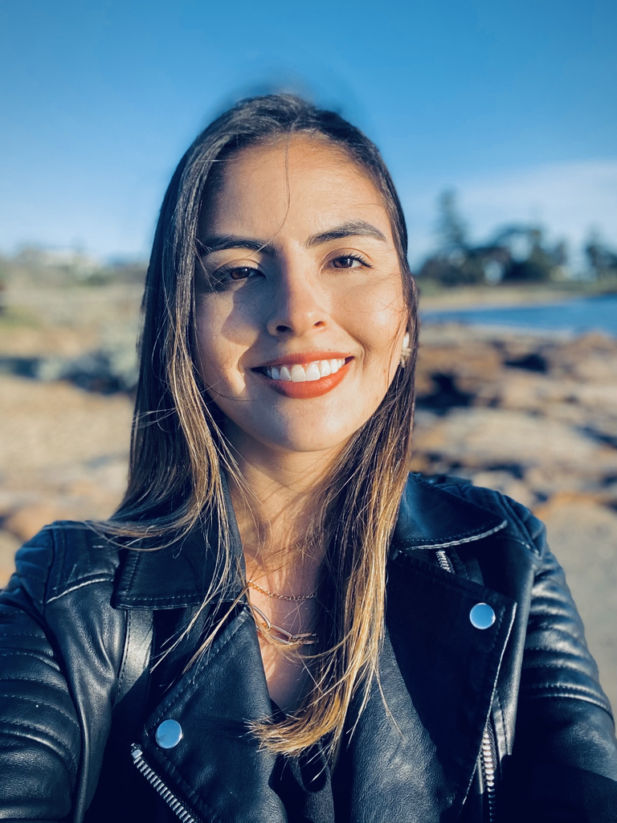

### 1. Display the first 10 rows of the dataset using RMarkdown (1 marks)

```r
thanksgiving<-read_csv("https://raw.githubusercontent.com/rfordatascience/tidytuesday/master/data/2018/2018-11-20/thanksgiving_meals.csv")
kable(head(thanksgiving, n=10, "pipe"))
```

| id | celebrate | main_dish | main_dish_other | main_prep | main_prep_other | stuffing | stuffing_other | cranberry | cranberry_other | gravy | side1 | side2 | side3 | side4 | side5 | side6 | side7 | side8 | side9 | side10 | side11 | side12 | side13 | side14 | side15 | pie1 | pie2 | pie3 | pie4 | … |
| --- | --- | --- | --- | --- | --- | --- | --- | --- | --- | --- | --- | --- | --- | --- | --- | --- | --- | --- | --- | --- | --- | --- | --- | --- | --- | --- | --- | --- | --- | --- |
| 4337954960 | Yes | Turkey | NA | Baked | NA | Bread-based | NA | None | NA | Yes | NA | Carrots | NA | NA | NA | NA | Green beans/green bean casserole | Macaroni and cheese | Mashed potatoes | NA | NA | NA | Yams/sweet potato casserole | NA | NA | Apple | NA | NA | NA | … |
| 4337951949 | Yes | Turkey | NA | Baked | NA | Bread-based | NA | Other (please specify) | Homemade cranberry gelatin ring | Yes | NA | NA | NA | Corn | NA | NA | Green beans/green bean casserole | Macaroni and cheese | Mashed potatoes | Rolls/biscuits | NA | Vegetable salad | Yams/sweet potato casserole | Other (please specify) | Asian vinagrette salad | Apple | NA | NA | Chocolate | … |
| 4337935621 | Yes | Turkey | NA | Roasted | NA | Rice-based | NA | Homemade | NA | Yes | Brussel sprouts | Carrots | Cauliflower | Corn | Cornbread | NA | NA | NA | Mashed potatoes | Rolls/biscuits | NA | Vegetable salad | NA | NA | NA | Apple | NA | Cherry | NA | … |
| 4337933040 | Yes | Turkey | NA | Baked | NA | Bread-based | NA | Homemade | NA | Yes | Brussel sprouts | NA | NA | NA | Cornbread | NA | NA | NA | Mashed potatoes | Rolls/biscuits | NA | Vegetable salad | Yams/sweet potato casserole | NA | NA | NA | NA | NA | NA | … |
| 4337931983 | Yes | Tofurkey | NA | Baked | NA | Bread-based | NA | Canned | NA | Yes | Brussel sprouts | NA | NA | NA | Cornbread | NA | NA | NA | Mashed potatoes | Rolls/biscuits | Squash | Vegetable salad | Yams/sweet potato casserole | NA | NA | Apple | NA | NA | NA | … |
| 4337929779 | Yes | Turkey | NA | Roasted | NA | Rice-based | NA | Homemade | NA | Yes | Brussel sprouts | Carrots | Cauliflower | Corn | Cornbread | Fruit salad | Green beans/green bean casserole | Macaroni and cheese | Mashed potatoes | Rolls/biscuits | Squash | Vegetable salad | Yams/sweet potato casserole | NA | NA | NA | NA | NA | NA | … |
| 4337924420 | Yes | Turkey | NA | Baked | NA | Bread-based | NA | Canned | NA | Yes | NA | NA | NA | NA | NA | Fruit salad | Green beans/green bean casserole | NA | Mashed potatoes | Rolls/biscuits | NA | NA | Yams/sweet potato casserole | NA | NA | Apple | NA | NA | NA | … |
| 4337916002 | Yes | Turkey | NA | Baked | NA | Rice-based | NA | Homemade | NA | Yes | NA | Carrots | NA | NA | NA | NA | NA | NA | NA | NA | NA | NA | NA | NA | NA | NA | NA | NA | Chocolate | … |
| 4337914977 | Yes | Turkey | NA | Roasted | NA | Bread-based | NA | Canned | NA | Yes | Brussel sprouts | NA | NA | Corn | Cornbread | NA | Green beans/green bean casserole | NA | Mashed potatoes | Rolls/biscuits | Squash | NA | NA | NA | NA | Apple | Buttermilk | NA | NA | … |
| 4337899817 | Yes | Other (please specify) | Turkey and Ham | Baked | NA | Bread-based | NA | Other (please specify) | Both Canned and Homemade | Yes | Brussel sprouts | Carrots | NA | NA | NA | NA | Green beans/green bean casserole | NA | Mashed potatoes | Rolls/biscuits | NA | NA | Yams/sweet potato casserole | NA | NA | NA | Buttermilk | NA | NA | … |

### 2. Use `fct_reorder` and `parse_number` functions to create a factor variable `family_income`

### I prefered to use `order` because `parse_number` change the data to numeric, so instead of changing again the variable to factor, I prefered just to use `order` and work directly with numeric data.

```r
thanksgiving2<-mutate(thanksgiving,family_income2=parse_number(family_income))
thanksgiving2<-thanksgiving2[order(thanksgiving2$family_income2),]
kable(head(thanksgiving2,n=10))
```

| id | celebrate | main_dish | main_dish_other | main_prep | main_prep_other | stuffing | stuffing_other | cranberry | cranberry_other | gravy | side1 | side2 | side3 | side4 | side5 | side6 | side7 | side8 | side9 | side10 | side11 | side12 | side13 | side14 | side15 | pie1 | pie2 | pie3 | pie4 | … |
| --- | --- | --- | --- | --- | --- | --- | --- | --- | --- | --- | --- | --- | --- | --- | --- | --- | --- | --- | --- | --- | --- | --- | --- | --- | --- | --- | --- | --- | --- | --- |
| 4337935621 | Yes | Turkey | NA | Roasted | NA | Rice-based | NA | Homemade | NA | Yes | Brussel sprouts | Carrots | Cauliflower | Corn | Cornbread | NA | NA | NA | Mashed potatoes | Rolls/biscuits | NA | Vegetable salad | NA | NA | NA | Apple | NA | Cherry | NA | … |
| 4337929779 | Yes | Turkey | NA | Roasted | NA | Rice-based | NA | Homemade | NA | Yes | Brussel sprouts | Carrots | Cauliflower | Corn | Cornbread | Fruit salad | Green beans/green bean casserole | Macaroni and cheese | Mashed potatoes | Rolls/biscuits | Squash | Vegetable salad | Yams/sweet potato casserole | NA | NA | NA | NA | NA | NA | … |
| 4337888291 | Yes | Ham/Pork | NA | Roasted | NA | Bread-based | NA | Canned | NA | Yes | NA | NA | NA | Corn | Cornbread | NA | NA | NA | Mashed potatoes | Rolls/biscuits | NA | NA | Yams/sweet potato casserole | NA | NA | NA | NA | Cherry | NA | … |
| 4337878450 | Yes | Turkey | NA | Baked | NA | Rice-based | NA | Homemade | NA | Yes | NA | NA | NA | NA | NA | NA | NA | NA | Mashed potatoes | Rolls/biscuits | NA | Vegetable salad | NA | NA | NA | Apple | NA | Cherry | Chocolate | … |
| 4337813502 | Yes | Turkey | NA | Fried | NA | None | NA | Homemade | NA | Yes | NA | NA | Cauliflower | Corn | Cornbread | NA | NA | NA | NA | NA | NA | NA | NA | NA | NA | NA | Buttermilk | Cherry | Chocolate | … |
| 4337809020 | No | NA | NA | NA | NA | NA | NA | NA | NA | NA | NA | NA | NA | NA | NA | NA | NA | NA | NA | NA | NA | NA | NA | NA | NA | NA | NA | NA | NA | … |
| 4337793158 | Yes | Turkey | NA | Baked | NA | Rice-based | NA | Homemade | NA | Yes | NA | Carrots | Cauliflower | NA | NA | NA | NA | NA | NA | NA | NA | NA | NA | NA | NA | Apple | Buttermilk | Cherry | NA | … |
| 4337725725 | No | NA | NA | NA | NA | NA | NA | NA | NA | NA | NA | NA | NA | NA | NA | NA | NA | NA | NA | NA | NA | NA | NA | NA | NA | NA | NA | NA | NA | … |
| 4337528775 | Yes | Turkey | NA | Baked | NA | Bread-based | NA | Canned | NA | Yes | NA | NA | NA | Corn | Cornbread | NA | Green beans/green bean casserole | Macaroni and cheese | Mashed potatoes | Rolls/biscuits | NA | NA | Yams/sweet potato casserole | NA | NA | Apple | NA | NA | NA | … |
| 4337429102 | Yes | Turkey | NA | Baked | NA | Bread-based | NA | Canned | NA | No | NA | NA | NA | Corn | Cornbread | NA | Green beans/green bean casserole | Macaroni and cheese | Mashed potatoes | Rolls/biscuits | NA | NA | Yams/sweet potato casserole | NA | NA | NA | NA | NA | NA | … |

### 3. Generate the general statistics of the dataset using `summary()` and `skim()` function (2 mark).

### General Statistics using `summary()`

```r
summary(thanksgiving)
```

```
##        id             celebrate          main_dish         main_dish_other
##  Min.   :4.336e+09   Length:1058        Length:1058        Length:1058
##  1st Qu.:4.336e+09   Class :character   Class :character   Class :character
##  Median :4.337e+09   Mode  :character   Mode  :character   Mode  :character
##  Mean   :4.337e+09
##  3rd Qu.:4.337e+09
##  Max.   :4.338e+09
##   main_prep         main_prep_other      stuffing         stuffing_other
##  Length:1058        Length:1058        Length:1058        Length:1058
##  Class :character   Class :character   Class :character   Class :character
##  Mode  :character   Mode  :character   Mode  :character   Mode  :character
##
##
##
##   cranberry         cranberry_other       gravy              side1
##  Length:1058        Length:1058        Length:1058        Length:1058
##  Class :character   Class :character   Class :character   Class :character
##  Mode  :character   Mode  :character   Mode  :character   Mode  :character
##
##
##
##     side2              side3              side4              side5
##  Length:1058        Length:1058        Length:1058        Length:1058
##  Class :character   Class :character   Class :character   Class :character
##  Mode  :character   Mode  :character   Mode  :character   Mode  :character
##
##
##
##     side6              side7              side8              side9
##  Length:1058        Length:1058        Length:1058        Length:1058
##  Class :character   Class :character   Class :character   Class :character
##  Mode  :character   Mode  :character   Mode  :character   Mode  :character
##
##
##
##     side10             side11             side12             side13
##  Length:1058        Length:1058        Length:1058        Length:1058
##  Class :character   Class :character   Class :character   Class :character
##  Mode  :character   Mode  :character   Mode  :character   Mode  :character
##
```

[output cut: 64 more lines]

```
##
##  community_type         age               gender          family_income
##  Length:1058        Length:1058        Length:1058        Length:1058
##  Class :character   Class :character   Class :character   Class :character
##  Mode  :character   Mode  :character   Mode  :character   Mode  :character
##
##
##
##   us_region
##  Length:1058
##  Class :character
##  Mode  :character
##
##
##
```

### General Statistics using `skim()`

```r
skim(thanksgiving)
```

Data summary

| Name | thanksgiving |
| --- | --- |
| Number of rows | 1058 |
| Number of columns | 65 |
| _______________________ |  |
| Column type frequency: |  |
| character | 64 |
| numeric | 1 |
| ________________________ |  |
| Group variables | None |

**Variable type: character**

| skim_variable | n_missing | complete_rate | min | max | empty | n_unique | whitespace |
| --- | --- | --- | --- | --- | --- | --- | --- |
| celebrate | 0 | 1.00 | 2 | 3 | 0 | 2 | 0 |
| main_dish | 84 | 0.92 | 6 | 22 | 0 | 8 | 0 |
| main_dish_other | 1023 | 0.03 | 4 | 85 | 0 | 32 | 0 |
| main_prep | 84 | 0.92 | 5 | 22 | 0 | 5 | 0 |
| main_prep_other | 1007 | 0.05 | 1 | 33 | 0 | 32 | 0 |
| stuffing | 84 | 0.92 | 4 | 22 | 0 | 4 | 0 |
| stuffing_other | 1022 | 0.03 | 4 | 46 | 0 | 29 | 0 |
| cranberry | 84 | 0.92 | 4 | 22 | 0 | 4 | 0 |
| cranberry_other | 1033 | 0.02 | 3 | 61 | 0 | 24 | 0 |
| gravy | 84 | 0.92 | 2 | 3 | 0 | 2 | 0 |
| side1 | 903 | 0.15 | 15 | 15 | 0 | 1 | 0 |
| side2 | 816 | 0.23 | 7 | 7 | 0 | 1 | 0 |
| side3 | 970 | 0.08 | 11 | 11 | 0 | 1 | 0 |
| side4 | 594 | 0.44 | 4 | 4 | 0 | 1 | 0 |
| side5 | 823 | 0.22 | 9 | 9 | 0 | 1 | 0 |
| side6 | 843 | 0.20 | 11 | 11 | 0 | 1 | 0 |
| side7 | 372 | 0.65 | 32 | 32 | 0 | 1 | 0 |
| side8 | 852 | 0.19 | 19 | 19 | 0 | 1 | 0 |
| side9 | 241 | 0.77 | 15 | 15 | 0 | 1 | 0 |
| side10 | 292 | 0.72 | 14 | 14 | 0 | 1 | 0 |
| side11 | 887 | 0.16 | 6 | 6 | 0 | 1 | 0 |
| side12 | 849 | 0.20 | 15 | 15 | 0 | 1 | 0 |
| side13 | 427 | 0.60 | 27 | 27 | 0 | 1 | 0 |
| side14 | 947 | 0.10 | 22 | 22 | 0 | 1 | 0 |
| side15 | 947 | 0.10 | 4 | 78 | 0 | 89 | 0 |
| pie1 | 544 | 0.49 | 5 | 5 | 0 | 1 | 0 |
| pie2 | 1023 | 0.03 | 10 | 10 | 0 | 1 | 0 |
| pie3 | 945 | 0.11 | 6 | 6 | 0 | 1 | 0 |
| pie4 | 925 | 0.13 | 9 | 9 | 0 | 1 | 0 |
| pie5 | 1022 | 0.03 | 13 | 13 | 0 | 1 | 0 |
| pie6 | 1019 | 0.04 | 8 | 8 | 0 | 1 | 0 |
| pie7 | 1024 | 0.03 | 5 | 5 | 0 | 1 | 0 |
| pie8 | 716 | 0.32 | 5 | 5 | 0 | 1 | 0 |
| pie9 | 329 | 0.69 | 7 | 7 | 0 | 1 | 0 |
| pie10 | 906 | 0.14 | 12 | 12 | 0 | 1 | 0 |
| pie11 | 1018 | 0.04 | 4 | 4 | 0 | 1 | 0 |
| pie12 | 987 | 0.07 | 22 | 22 | 0 | 1 | 0 |
| pie13 | 987 | 0.07 | 5 | 46 | 0 | 61 | 0 |
| dessert1 | 948 | 0.10 | 13 | 13 | 0 | 1 | 0 |
| dessert2 | 1042 | 0.02 | 8 | 8 | 0 | 1 | 0 |
| dessert3 | 930 | 0.12 | 8 | 8 | 0 | 1 | 0 |
| dessert4 | 986 | 0.07 | 11 | 11 | 0 | 1 | 0 |
| dessert5 | 867 | 0.18 | 10 | 10 | 0 | 1 | 0 |
| dessert6 | 854 | 0.19 | 7 | 7 | 0 | 1 | 0 |
| dessert7 | 1015 | 0.04 | 5 | 5 | 0 | 1 | 0 |
| dessert8 | 792 | 0.25 | 9 | 9 | 0 | 1 | 0 |
| dessert9 | 955 | 0.10 | 13 | 13 | 0 | 1 | 0 |
| dessert10 | 763 | 0.28 | 4 | 4 | 0 | 1 | 0 |
| dessert11 | 924 | 0.13 | 22 | 22 | 0 | 1 | 0 |
| dessert12 | 924 | 0.13 | 3 | 59 | 0 | 92 | 0 |
| prayer | 99 | 0.91 | 2 | 3 | 0 | 2 | 0 |
| travel | 107 | 0.90 | 59 | 80 | 0 | 4 | 0 |
| watch_program | 556 | 0.47 | 13 | 13 | 0 | 1 | 0 |
| kids_table_age | 107 | 0.90 | 2 | 13 | 0 | 12 | 0 |
| hometown_friends | 107 | 0.90 | 2 | 3 | 0 | 2 | 0 |
| friendsgiving | 107 | 0.90 | 2 | 3 | 0 | 2 | 0 |
| black_friday | 107 | 0.90 | 2 | 3 | 0 | 2 | 0 |
| work_retail | 107 | 0.90 | 2 | 3 | 0 | 2 | 0 |
| work_black_friday | 988 | 0.07 | 2 | 13 | 0 | 3 | 0 |
| community_type | 110 | 0.90 | 5 | 8 | 0 | 3 | 0 |
| age | 33 | 0.97 | 3 | 7 | 0 | 4 | 0 |
| gender | 33 | 0.97 | 4 | 6 | 0 | 2 | 0 |
| family_income | 33 | 0.97 | 12 | 20 | 0 | 11 | 0 |
| us_region | 59 | 0.94 | 7 | 18 | 0 | 9 | 0 |

**Variable type: numeric**

| skim_variable | n_missing | complete_rate | mean | sd | p0 | p25 | p50 | p75 | p100 | hist |
| --- | --- | --- | --- | --- | --- | --- | --- | --- | --- | --- |
| id | 0 | 1 | 4336731188 | 493783.4 | 4335894916 | 4336339486 | 4336796628 | 4337012140 | 4337954960 | ▅▃▇▂▂ |

### 4. What is the number of people who celebrate?

```r
people<-thanksgiving%>%count(celebrate,name="Number of People",sort = TRUE)
people<-people[-c(2),]
kable(people)
```

| celebrate | Number of People |
| --- | --- |
| Yes | 980 |

### 5. What are categories and stats for each main dish served and the method it is prepared?

### Total Comparison

```r
main<-thanksgiving%>%count(main_dish,main_prep, name="Number of People", sort=TRUE)
main<-main[-c(3,17,25,26),]
kable(main)
```

| main_dish | main_prep | Number of People |
| --- | --- | --- |
| Turkey | Baked | 422 |
| Turkey | Roasted | 351 |
| Turkey | Fried | 41 |
| Turkey | Other (please specify) | 34 |
| Ham/Pork | Baked | 22 |
| Other (please specify) | Baked | 16 |
| Tofurkey | Baked | 14 |
| Other (please specify) | Other (please specify) | 12 |
| Turkey | I don’t know | 11 |
| Ham/Pork | Roasted | 5 |
| Other (please specify) | Roasted | 5 |
| Roast beef | Roasted | 5 |
| Chicken | Baked | 4 |
| Chicken | Roasted | 4 |
| Tofurkey | Roasted | 4 |
| Roast beef | Baked | 3 |
| Turducken | Roasted | 3 |
| Chicken | Fried | 2 |
| Chicken | Other (please specify) | 2 |
| Roast beef | Fried | 2 |
| Ham/Pork | I don’t know | 1 |
| Ham/Pork | Other (please specify) | 1 |
| Other (please specify) | Fried | 1 |
| Other (please specify) | I don’t know | 1 |
| Roast beef | Other (please specify) | 1 |
| Tofurkey | I don’t know | 1 |
| Tofurkey | Other (please specify) | 1 |

### Comparison Main Dish

```r
main_dish<-thanksgiving%>%count(main_dish,name="Number of People",sort=TRUE)
main_dish<-main_dish[-c(2,8),]
kable(main_dish)
```

| main_dish | Number of People |
| --- | --- |
| Turkey | 859 |
| Other (please specify) | 35 |
| Ham/Pork | 29 |
| Tofurkey | 20 |
| Chicken | 12 |
| Roast beef | 11 |
| Turducken | 3 |

### Comparison Preparation Method

```r
main_prep<-thanksgiving%>%count(main_prep,name="Number of People",sort=TRUE)
main_prep<-main_prep[-c(3,6),]
kable(main_prep)
```

| main_prep | Number of People |
| --- | --- |
| Baked | 481 |
| Roasted | 378 |
| Other (please specify) | 51 |
| Fried | 47 |

### 6. Create a data viz showing this in the most evident way. Provide your own legend and use themes.

### Total Comparison

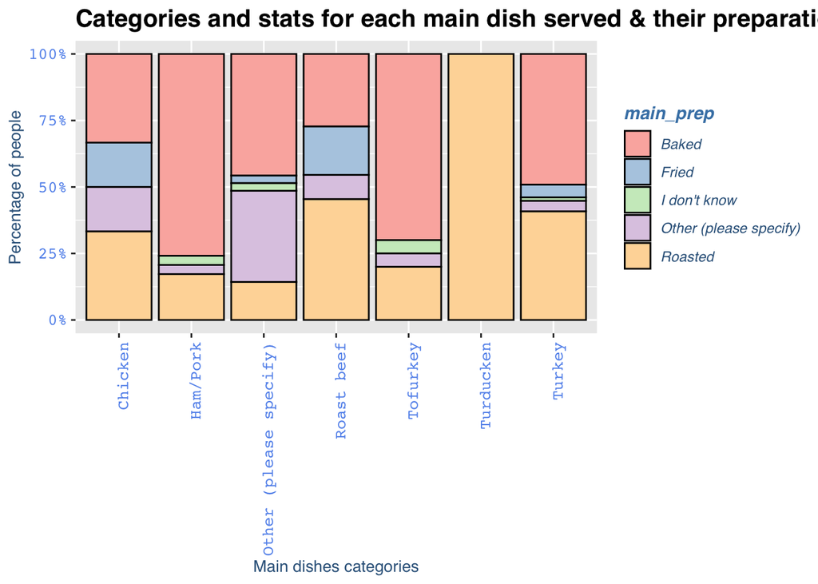

```r
ggp<-ggplot(main,
              aes(x = main_dish,
                  y = `Number of People`,
                  fill = main_prep)) +
  geom_bar(position = "fill", stat = "identity",colour = "black")+
scale_y_continuous(labels = scales::percent_format()) +
  scale_fill_brewer(palette="Pastel1")+
  labs(y= "Percentage of people", x = "Main dishes categories", title="Categories and stats for each main dish served & their preparation methods")+
  theme(plot.title = element_text(family = "Helvetica", face = "bold", size = (15)),
                 legend.title = element_text(colour = "steelblue",  face = "bold.italic", family = "Helvetica"),
                 legend.text = element_text(face = "italic", colour="steelblue4",family = "Helvetica"),
                  axis.title = element_text(family = "Helvetica", size = (10), colour = "steelblue4"),
                  axis.text = element_text(family = "Courier", colour = "cornflowerblue", size = (10)),
                  axis.text.x = element_text(angle = 90,hjust = 1))
ggp
```

### 7. How many use cranberry sauce? How many use gravy?

### How many use cranberry sauce?

```r
crb<-thanksgiving%>%count(cranberry, name="People that use Cranberry Sauce", sort=TRUE)
crb <-crb[-c(3,4),]%>%adorn_totals()
kable(crb)
```

| cranberry | People that use Cranberry Sauce |
| --- | --- |
| Canned | 502 |
| Homemade | 301 |
| Other (please specify) | 25 |
| Total | 828 |

### How many use gravy?

```r
grv<-thanksgiving%>%count(gravy, name="People that use Gravy sauce", sort=TRUE)
grv <-grv[-c(2,3),]
kable(grv)
```

| gravy | People that use Gravy sauce |
| --- | --- |
| Yes | 892 |

### 8. What is the distribution of those who celebrate across income ranges

```r
dtb<-thanksgiving2%>%
  filter(celebrate=="Yes")%>%
  count(family_income2,celebrate)
dtb<-dtb[-c(11,12),]
dtb<-subset(dtb,select = -c(celebrate))

dtb$family_income2 <- as.numeric(dtb$family_income2)
dtb$n <- as.numeric(dtb$n)
colnames(dtb) <- c("Family Income","Number of People")
kable(dtb)
```

| Family Income | Number of People |
| --- | --- |
| 0 | 52 |
| 10000 | 60 |
| 25000 | 166 |
| 50000 | 127 |
| 75000 | 127 |
| 100000 | 109 |
| 125000 | 48 |
| 150000 | 38 |
| 175000 | 26 |
| 200000 | 76 |

### 9. Present this information in the most evident way on the data viz.

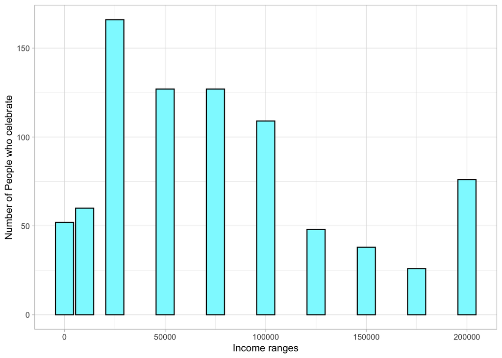

```r
dtb%>%ggplot(aes(x=`Family Income`,y=`Number of People`))+
  geom_col(position = "dodge",colour="black",fill="#8cf9ff")+
  theme_light(base_size = 10)+
    labs(
    x = "Income ranges",
    y = "Number of People who celebrate",
    fill = NULL)
```

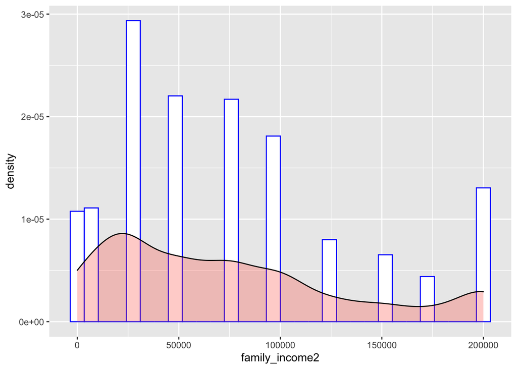

```r
ggplot(thanksgiving2, aes(x = family_income2)) +
  geom_histogram(aes(y = ..density..),
                 colour = "blue", fill = "white") +
  geom_density(alpha = .3, fill="#FF6655")
```

### 10. What are the most common pies, sides, and desserts? Present this information on a data viz

### Most Common Thanksgiving Pies + Data Vis

```r
pie1<-thanksgiving%>%
  filter(!is.na(pie1))%>%
  count(pie1)
  colnames(pie1) <- c("pies","n")


pie2<-thanksgiving%>%
  filter(!is.na(pie2))%>%
  count(pie2)
  colnames(pie2) <- c("pies","n")


pie3<-thanksgiving%>%
  filter(!is.na(pie3))%>%
  count(pie3)
  colnames(pie3) <- c("pies","n")


pie4<-thanksgiving%>%
  filter(!is.na(pie4))%>%
  count(pie4)
  colnames(pie4) <- c("pies","n")


pie5<-thanksgiving%>%
  filter(!is.na(pie5))%>%
  count(pie5)
  colnames(pie5) <- c("pies","n")


pie6<-thanksgiving%>%
  filter(!is.na(pie6))%>%
  count(pie6)
  colnames(pie6) <- c("pies","n")


pie7<-thanksgiving%>%
  filter(!is.na(pie7))%>%
  count(pie7)
  colnames(pie7) <- c("pies","n")


pie8<-thanksgiving%>%
  filter(!is.na(pie8))%>%
  count(pie8)
  colnames(pie8) <- c("pies","n")


pie9<-thanksgiving%>%
  filter(!is.na(pie9))%>%
  count(pie9)
  colnames(pie9) <- c("pies","n")


pie10<-thanksgiving%>%
  filter(!is.na(pie10))%>%
  count(pie10)
  colnames(pie10) <- c("pies","n")


pie11<-thanksgiving%>%
  filter(!is.na(pie11))%>%
  count(pie11)
  colnames(pie11) <- c("pies","n")


pie13<-thanksgiving%>%
  filter(!is.na(pie13))%>%
  count(pie13)%>%adorn_totals(name = "Others")
  pie13 <-pie13[-c(1:61),]
  colnames(pie13) <- c("pies","n")


pies_total <- bind_rows(pie1,pie2,pie3,pie4,pie5,pie6,pie7,pie8,pie9,pie10,pie11,pie13)

pies_total <- pies_total[order(-pies_total$n),]

colnames(pies_total) <- c("Pies","People")

kable(pies_total)
```

| Pies | People |
| --- | --- |
| Pumpkin | 729 |
| Apple | 514 |
| Pecan | 342 |
| Sweet Potato | 152 |
| Chocolate | 133 |
| Cherry | 113 |
| Others | 71 |
| None | 40 |
| Key lime | 39 |
| Coconut cream | 36 |
| Buttermilk | 35 |
| Peach | 34 |

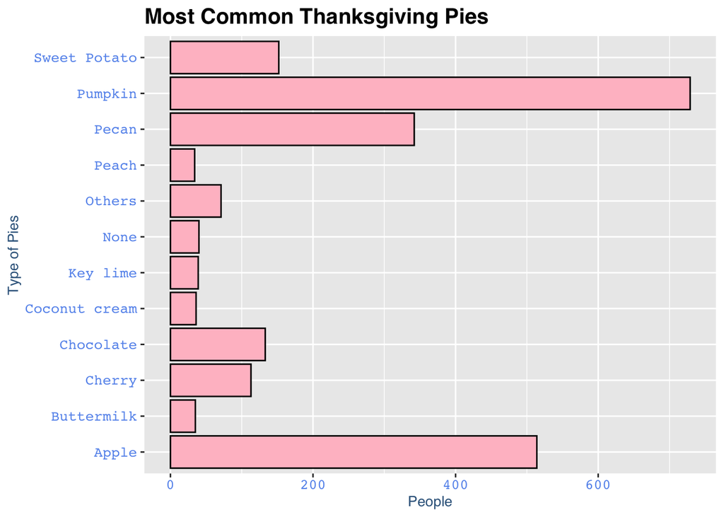

```r
plotpies<-ggplot(pies_total,
              aes(x = People,
                  y = Pies)) +
  geom_bar(stat="identity", position=position_dodge(),colour = "black",fill="pink")+
  labs(y= "Type of Pies", x = "People", title="Most Common Thanksgiving Pies")+
  theme(plot.title = element_text(family = "Helvetica", face = "bold", size = (15)),
                 legend.title = element_text(colour = "steelblue",  face = "bold.italic", family = "Helvetica"),
                 legend.text = element_text(face = "italic", colour="steelblue4",family = "Helvetica"),
                  axis.title = element_text(family = "Helvetica", size = (10), colour = "steelblue4"),
                  axis.text = element_text(family = "Courier", colour = "cornflowerblue", size = (10)))
plotpies
```

### Most Common Thanksgiving Sides + Data Vis

```r
side1<-thanksgiving%>%
  filter(!is.na(side1))%>%
  count(side1)
  colnames(side1) <- c("sides","n")


side2<-thanksgiving%>%
  filter(!is.na(side2))%>%
  count(side2)
  colnames(side2) <- c("sides","n")


side3<-thanksgiving%>%
  filter(!is.na(side3))%>%
  count(side3)
  colnames(side3) <- c("sides","n")


side4<-thanksgiving%>%
  filter(!is.na(side4))%>%
  count(side4)
  colnames(side4) <- c("sides","n")


side5<-thanksgiving%>%
  filter(!is.na(side5))%>%
  count(side5)
  colnames(side5) <- c("sides","n")


side6<-thanksgiving%>%
  filter(!is.na(side6))%>%
  count(side6)
  colnames(side6) <- c("sides","n")


side7<-thanksgiving%>%
  filter(!is.na(side7))%>%
  count(side7)
  colnames(side7) <- c("sides","n")


side8<-thanksgiving%>%
  filter(!is.na(side8))%>%
  count(side8)
  colnames(side8) <- c("sides","n")


side9<-thanksgiving%>%
  filter(!is.na(side9))%>%
  count(side9)
  colnames(side9) <- c("sides","n")


side10<-thanksgiving%>%
  filter(!is.na(side10))%>%
  count(side10)
  colnames(side10) <- c("sides","n")


side11<-thanksgiving%>%
  filter(!is.na(side11))%>%
  count(side11)
  colnames(side11) <- c("sides","n")


side12<-thanksgiving%>%
  filter(!is.na(side12))%>%
  count(side12)
  colnames(side12) <- c("sides","n")

side13<-thanksgiving%>%
  filter(!is.na(side13))%>%
  count(side13)
  colnames(side13) <- c("sides","n")

side15<-thanksgiving%>%
  filter(!is.na(side15))%>%
  count(side15)%>%adorn_totals(name = "Others")
  side15 <-side15[-c(1:89),]
  colnames(side15) <- c("sides","n")


sides_total <- bind_rows(side1,side2,side3,side4,side5,side6,side7,side8,side9,side10,side11,side12,side13,side15)

sides_total <- sides_total[order(-sides_total$n),]

colnames(sides_total) <- c("Sides","People")

kable(sides_total)
```

| Sides | People |
| --- | --- |
| Mashed potatoes | 817 |
| Rolls/biscuits | 766 |
| Green beans/green bean casserole | 686 |
| Yams/sweet potato casserole | 631 |
| Corn | 464 |
| Carrots | 242 |
| Cornbread | 235 |
| Fruit salad | 215 |
| Vegetable salad | 209 |
| Macaroni and cheese | 206 |
| Squash | 171 |
| Brussel sprouts | 155 |
| Others | 111 |
| Cauliflower | 88 |

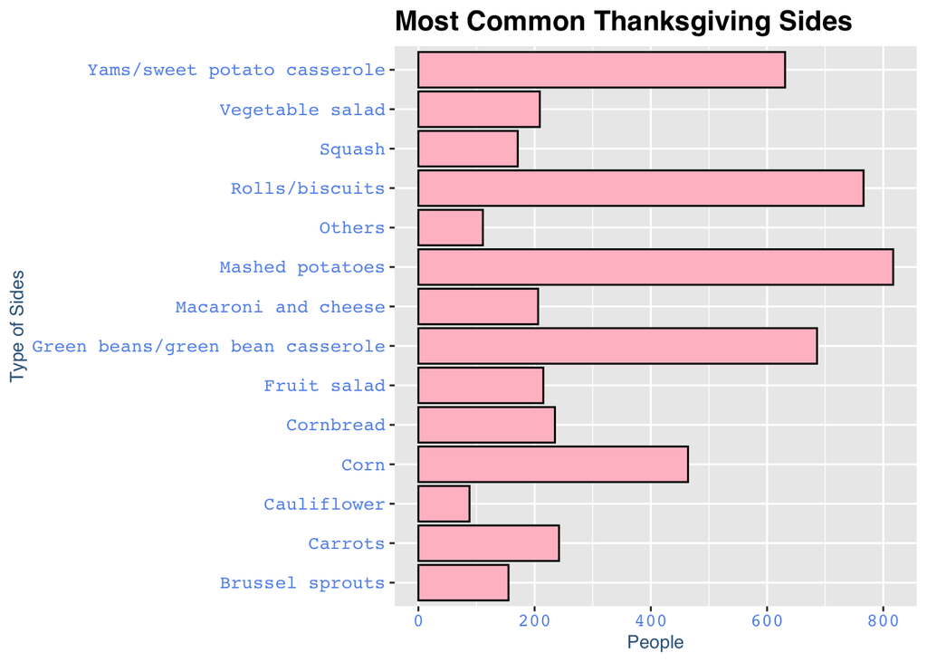

```r
plotsides<-ggplot(sides_total,
              aes(x = People,
                  y = Sides)) +
  geom_bar(stat="identity", position=position_dodge(),colour = "black",fill="pink")+
  labs(y= "Type of Sides", x = "People", title="Most Common Thanksgiving Sides")+
  theme(plot.title = element_text(family = "Helvetica", face = "bold", size = (15)),
                 legend.title = element_text(colour = "steelblue",  face = "bold.italic", family = "Helvetica"),
                 legend.text = element_text(face = "italic", colour="steelblue4",family = "Helvetica"),
                  axis.title = element_text(family = "Helvetica", size = (10), colour = "steelblue4"),
                  axis.text = element_text(family = "Courier", colour = "cornflowerblue", size = (10)))
plotsides
```

### Most Common Thanksgiving Desserts + Data Vis

```r
dessert1<-thanksgiving%>%
  filter(!is.na(dessert1))%>%
  count(dessert1)
  colnames(dessert1) <- c("dessert","n")


dessert2<-thanksgiving%>%
  filter(!is.na(dessert2))%>%
  count(dessert2)
  colnames(dessert2) <- c("dessert","n")


dessert3<-thanksgiving%>%
  filter(!is.na(dessert3))%>%
  count(dessert3)
  colnames(dessert3) <- c("dessert","n")


dessert4<-thanksgiving%>%
  filter(!is.na(dessert4))%>%
  count(dessert4)
  colnames(dessert4) <- c("dessert","n")


dessert5<-thanksgiving%>%
  filter(!is.na(dessert5))%>%
  count(dessert5)
  colnames(dessert5) <- c("dessert","n")


dessert6<-thanksgiving%>%
  filter(!is.na(dessert6))%>%
  count(dessert6)
  colnames(dessert6) <- c("dessert","n")


dessert7<-thanksgiving%>%
  filter(!is.na(dessert7))%>%
  count(dessert7)
  colnames(dessert7) <- c("dessert","n")


dessert8<-thanksgiving%>%
  filter(!is.na(dessert8))%>%
  count(dessert8)
  colnames(dessert8) <- c("dessert","n")


dessert9<-thanksgiving%>%
  filter(!is.na(dessert9))%>%
  count(dessert9)
  colnames(dessert9) <- c("dessert","n")


dessert10<-thanksgiving%>%
  filter(!is.na(dessert10))%>%
  count(dessert10)
  colnames(dessert10) <- c("dessert","n")

dessert12<-thanksgiving%>%
  filter(!is.na(dessert12))%>%
  count(dessert12)%>%adorn_totals(name = "Others")
  dessert12 <-dessert12[-c(1:92),]
  colnames(dessert12) <- c("dessert","n")


dessert_total <- bind_rows(dessert1,dessert2,dessert3,dessert4,dessert5,dessert6,dessert7,dessert8,dessert9,dessert10,dessert12)

dessert_total <- dessert_total[order(-dessert_total$n),]

colnames(dessert_total) <- c("Dessert","People")

kable(dessert_total)
```

| Dessert | People |
| --- | --- |
| None | 295 |
| Ice cream | 266 |
| Cookies | 204 |
| Cheesecake | 191 |
| Others | 134 |
| Brownies | 128 |
| Apple cobbler | 110 |
| Peach cobbler | 103 |
| Carrot cake | 72 |
| Fudge | 43 |
| Blondies | 16 |

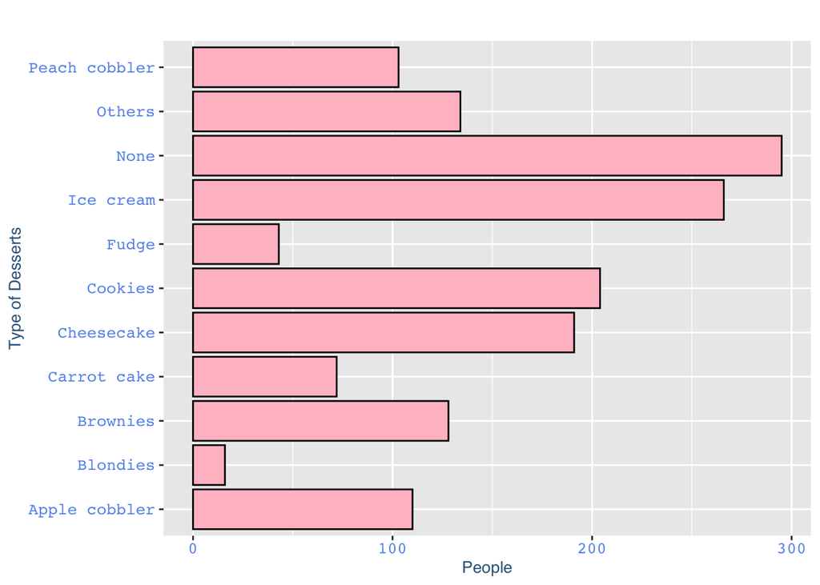

```r
plotdessert<-ggplot(dessert_total,
              aes(x = People,
                  y = Dessert)) +
  geom_bar(stat="identity", position=position_dodge(),colour = "black",fill="pink")+
  labs(y= "Type of Desserts", x = "People", title="")+
  theme(plot.title = element_text(family = "Helvetica", face = "bold", size = (15)),
                 legend.title = element_text(colour = "steelblue",  face = "bold.italic", family = "Helvetica"),
                 legend.text = element_text(face = "italic", colour="steelblue4",family = "Helvetica"),
                  axis.title = element_text(family = "Helvetica", size = (10), colour = "steelblue4"),
                  axis.text = element_text(family = "Courier", colour = "cornflowerblue", size = (10)))
plotdessert
```

### 12. How do the servings differ by income?

```r
servings<-thanksgiving%>%count(main_dish,family_income, name="Number of People", sort=TRUE)

servings<-servings%>%filter(!is.na(servings))

servings<-servings[-c(4,11,19,27,29,33,39,49,50,51,52,53,57,62),]

kable(servings)
```

| main_dish | family_income | Number of People |
| --- | --- | --- |
| Turkey | $25,000 to $49,999 | 144 |
| Turkey | $50,000 to $74,999 | 118 |
| Turkey | $75,000 to $99,999 | 112 |
| Turkey | $100,000 to $124,999 | 99 |
| Turkey | $200,000 and up | 68 |
| Turkey | $10,000 to $24,999 | 47 |
| Turkey | $0 to $9,999 | 43 |
| Turkey | $125,000 to $149,999 | 43 |
| Turkey | $150,000 to $174,999 | 34 |
| Turkey | $175,000 to $199,999 | 23 |
| Ham/Pork | $75,000 to $99,999 | 8 |
| Other (please specify) | $25,000 to $49,999 | 8 |
| Ham/Pork | $25,000 to $49,999 | 6 |
| Other (please specify) | $75,000 to $99,999 | 5 |
| Ham/Pork | $10,000 to $24,999 | 4 |
| Other (please specify) | $100,000 to $124,999 | 4 |
| Tofurkey | $25,000 to $49,999 | 4 |
| Chicken | $10,000 to $24,999 | 3 |
| Chicken | $25,000 to $49,999 | 3 |
| Other (please specify) | $10,000 to $24,999 | 3 |
| Other (please specify) | $50,000 to $74,999 | 3 |
| Roast beef | $0 to $9,999 | 3 |
| Tofurkey | $100,000 to $124,999 | 3 |
| Chicken | $0 to $9,999 | 2 |
| Ham/Pork | $100,000 to $124,999 | 2 |
| Ham/Pork | $200,000 and up | 2 |
| Ham/Pork | $50,000 to $74,999 | 2 |
| Other (please specify) | $125,000 to $149,999 | 2 |
| Other (please specify) | $150,000 to $174,999 | 2 |
| Other (please specify) | $175,000 to $199,999 | 2 |
| Other (please specify) | $200,000 and up | 2 |
| Roast beef | $50,000 to $74,999 | 2 |
| Tofurkey | $10,000 to $24,999 | 2 |
| Tofurkey | $125,000 to $149,999 | 2 |
| Tofurkey | $75,000 to $99,999 | 2 |
| Turducken | $200,000 and up | 2 |
| Chicken | $100,000 to $124,999 | 1 |
| Chicken | $200,000 and up | 1 |
| Ham/Pork | $0 to $9,999 | 1 |
| Ham/Pork | $125,000 to $149,999 | 1 |
| Ham/Pork | $150,000 to $174,999 | 1 |
| Roast beef | $10,000 to $24,999 | 1 |
| Roast beef | $150,000 to $174,999 | 1 |
| Roast beef | $25,000 to $49,999 | 1 |
| Tofurkey | $0 to $9,999 | 1 |
| Tofurkey | $175,000 to $199,999 | 1 |
| Tofurkey | $200,000 and up | 1 |
| Tofurkey | $50,000 to $74,999 | 1 |

```r
serving_no_turkey<-servings%>%filter(main_dish!='Turkey')
```

### 13. Present this information on a data viz

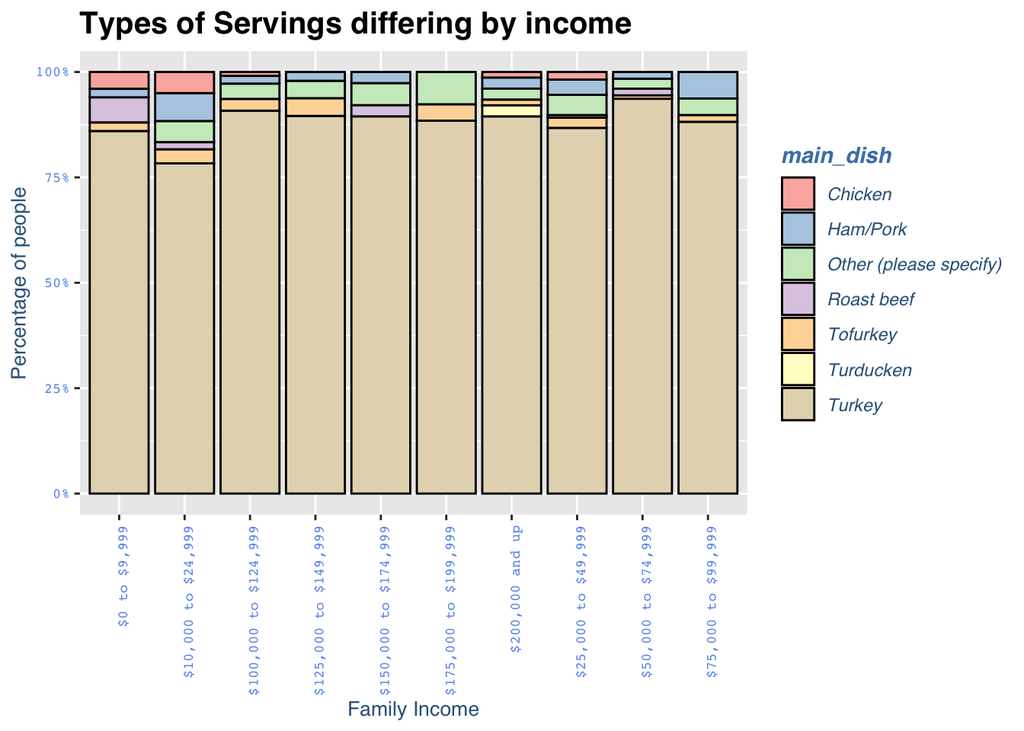

```r
srv<-ggplot(servings,
              aes(x = family_income,
                  y = `Number of People`,
                  fill = main_dish)) +
  geom_bar(position = "fill", stat = "identity",colour = "black")+
scale_y_continuous(labels = scales::percent_format()) +
  scale_fill_brewer(palette="Pastel1")+
  labs(y= "Percentage of people", x = "Family Income", title="Types of Servings differing by income")+
  theme(plot.title = element_text(family = "Helvetica", face = "bold", size = (15)),
                 legend.title = element_text(colour = "steelblue",  face = "bold.italic", family = "Helvetica"),
                 legend.text = element_text(face = "italic", colour="steelblue4",family = "Helvetica"),
                  axis.title = element_text(family = "Helvetica", size = (10), colour = "steelblue4"),
                  axis.text = element_text(family = "Courier", colour = "cornflowerblue", size = (7)),
                  axis.text.x = element_text(angle = 90,hjust = 1))
srv
```

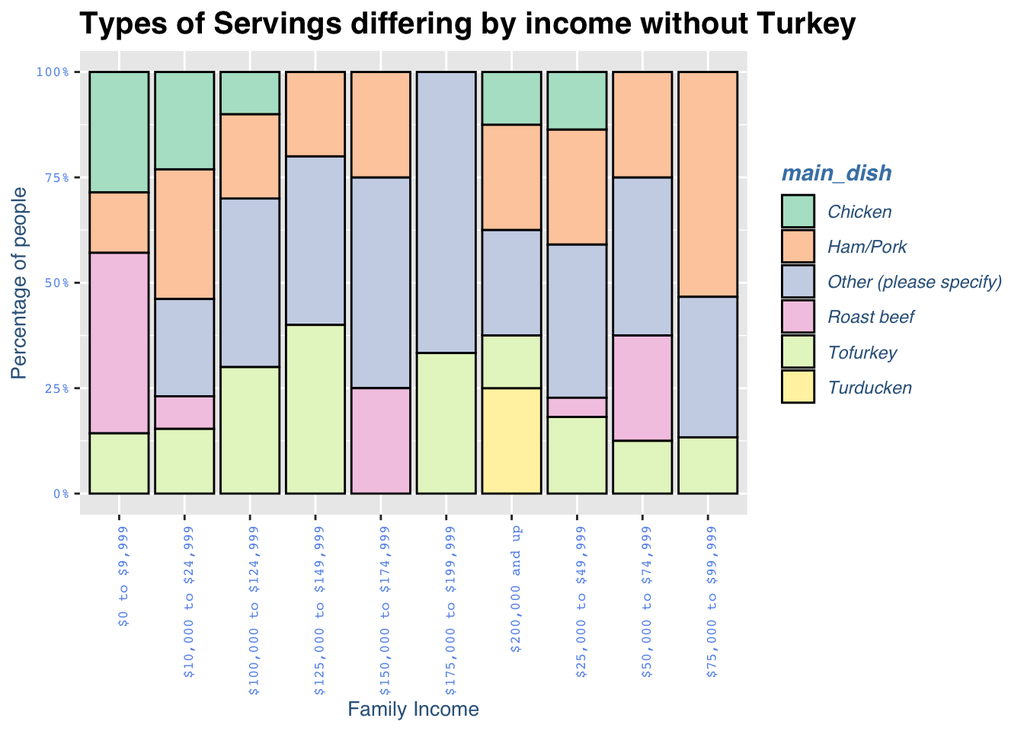

```r
srv2<-ggplot(serving_no_turkey,
              aes(x = family_income,
                  y = `Number of People`,
                  fill = main_dish)) +
  geom_bar(position = "fill", stat = "identity",colour = "black")+
scale_y_continuous(labels = scales::percent_format()) +
  scale_fill_brewer(palette="Pastel2")+
  labs(y= "Percentage of people", x = "Family Income", title="Types of Servings differing by income without Turkey")+
  theme(plot.title = element_text(family = "Helvetica", face = "bold", size = (15)),
                 legend.title = element_text(colour = "steelblue",  face = "bold.italic", family = "Helvetica"),
                 legend.text = element_text(face = "italic", colour="steelblue4",family = "Helvetica"),
                  axis.title = element_text(family = "Helvetica", size = (10), colour = "steelblue4"),
                  axis.text = element_text(family = "Courier", colour = "cornflowerblue", size = (7)),
                  axis.text.x = element_text(angle = 90,hjust = 1))
srv2
```